**Loading and cleaning up data**

Load libraries and data.

```r
library(ggplot2);library(caret);library(randomForest);library(rattle)
library(rpart);library(rpart.plot)
traindata<-read.csv("training.csv", na.strings=c("", "NA"), header= TRUE)
testdata<-read.csv("testing.csv", header= TRUE)
```

There are many columns in the traindata with a large proportion (over 90%) of missing data. I chose to keep only columns that have less than 10000 NAs. Now there are no missing data in the dataset.

```r
count <- sapply(traindata, is.na);count <- colSums(count);
traindata <- traindata[,count<10000]
```

The first seven variables are subject IDs, timestamps and are likely unrelated to activity class. I removed thsee and convered the data to numeric, while leave the “classe” variable as a factor.

```r
traindata<-traindata[,-c(1:7)];
traindata[,1:52]<-as.numeric(as.matrix(traindata[,1:52]))
```

Next, I removed highly correlated variables with a coeffecient greater than .75. Now the dataset has 32 predictors and one outcome, “classe”.

```r
traindataCor <-  cor(traindata[,1:52])
high.corr<-findCorrelation(traindataCor, cutoff=.75)
traindata<-traindata[,-high.corr]
```

**Cross Validation Method**

I split the training data into subset 70% in training 30% test. This will allow for a hold-out method of cross validation when testing model accuracy later.

```r
inTrain<-createDataPartition(y=traindata$classe, p=.70, list=FALSE)
subtraining<-traindata[inTrain,]
subtest<-traindata[-inTrain,]
```

**Building Classification Models**

The first model I created is a recursive partitioning model with the rpart package.

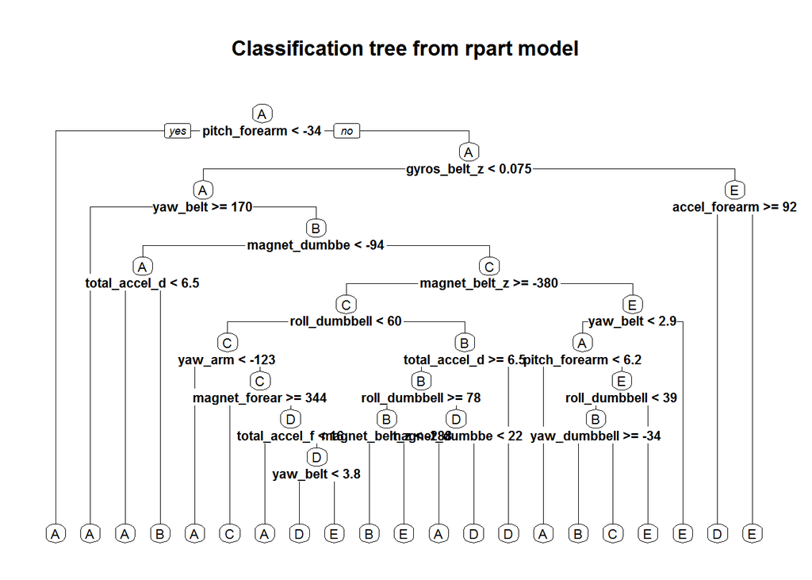

```r
set.seed(3780)
modelrpart<-rpart(classe~., data= subtraining, method = "class")
prp(modelrpart,main = "Classification tree from rpart model",
        type=2, cex = .7, fallen.leaves= TRUE)
```

```r
prediction<-predict(modelrpart, newdata=subtest, type = "class")
confusionMatrix(prediction, subtest$classe)
```

```
## Confusion Matrix and Statistics
##
##           Reference
## Prediction    A    B    C    D    E
##          A 1291  131   24   32   25
##          B  109  556   80   45   90
##          C  162  249  808  275  137
##          D   91  161   56  581   66
##          E   21   42   58   31  764
##
## Overall Statistics
##
##                Accuracy : 0.6797
##                  95% CI : (0.6676, 0.6916)
##     No Information Rate : 0.2845
##     P-Value [Acc > NIR] : < 2.2e-16
##
##                   Kappa : 0.597
##  Mcnemar's Test P-Value : < 2.2e-16
##
## Statistics by Class:
##
##                      Class: A Class: B Class: C Class: D Class: E
## Sensitivity            0.7712  0.48815   0.7875  0.60270   0.7061
## Specificity            0.9497  0.93173   0.8306  0.92400   0.9684
## Pos Pred Value         0.8589  0.63182   0.4954  0.60838   0.8341
## Neg Pred Value         0.9126  0.88352   0.9488  0.92231   0.9360
## Prevalence             0.2845  0.19354   0.1743  0.16381   0.1839
## Detection Rate         0.2194  0.09448   0.1373  0.09873   0.1298
## Detection Prevalence   0.2554  0.14953   0.2771  0.16228   0.1556
## Balanced Accuracy      0.8604  0.70994   0.8091  0.76335   0.8372
```

```r
pred.table<-table(prediction,subtest$classe)/length(subtest$classe)
sum(diag(pred.table))
```

```
## [1] 0.6796941
```

**The Random Forest Model**

The random forest model constructs trees using a bootstrap sample of the data (bootstrap with replacement). Each tree is constructed with about 1/3 of the data. The out-of-bag data is used to get a running estimate of the classification error, which eliminates the need for cross-validation like we did with the rpart model previously. This particular RF model was constructed with only 100 trees for increased speed gives 99.13% accuracy and out-of-bat (OOB) error rate less than one percent (.84%).

```r
set.seed(1234)
modelFit<-randomForest(classe~., data = subtraining,
        type = "rf", ntree=100, proximity=TRUE)
modelFit
```

```
##
## Call:
##  randomForest(formula = classe ~ ., data = subtraining, type = "rf",      ntree = 100, proximity = TRUE)
##                Type of random forest: classification
##                      Number of trees: 100
## No. of variables tried at each split: 5
##
##         OOB estimate of  error rate: 0.84%
## Confusion matrix:
##      A    B    C    D    E class.error
## A 3902    3    0    0    1 0.001024066
## B   23 2624    8    1    2 0.012791573
## C    0   21 2354   21    0 0.017529215
## D    1    0   22 2224    5 0.012433393
## E    0    1    1    6 2517 0.003168317
```

In the random forest model, the error rate drastically declines in the first 20 trees and levels out at after about 40 to 50 trees have been drawn. I would not expect to get much more accuracy by increasing number of trees for this particular dataset.

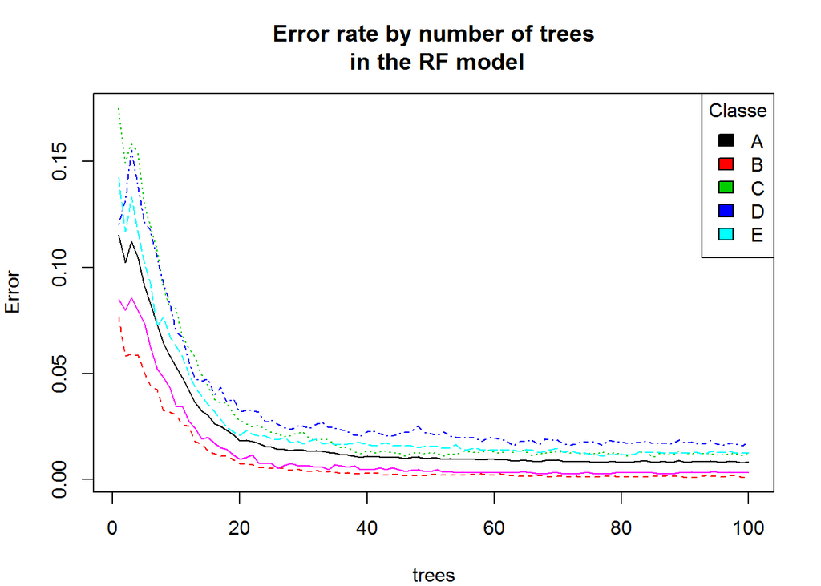

```r
par(mar=c(4,4,4,2))
plot(modelFit, main = "Error rate by number of trees\n in the RF model")
legend("topright", title = "Classe", legend=unique(modelFit$classe),
        col=unique(as.numeric(modelFit$classe)), fill=1:5, pch=19)
```

Using the RF model to predict “classe” from the subtest data, shows this model is quite accurate (99%). The confusion matrix shows most are classified correctly.

```r
predictions<-predict(modelFit, newdata=subtest)
confusionMatrix(predictions, subtest$classe)
```

```
## Confusion Matrix and Statistics
##
##           Reference
## Prediction    A    B    C    D    E
##          A 1671    4    0    0    0
##          B    3 1128   14    0    0
##          C    0    5 1006   13    2
##          D    0    1    6  949    0
##          E    0    1    0    2 1080
##
## Overall Statistics
##
##                Accuracy : 0.9913
##                  95% CI : (0.9886, 0.9935)
##     No Information Rate : 0.2845
##     P-Value [Acc > NIR] : < 2.2e-16
##
##                   Kappa : 0.989
##  Mcnemar's Test P-Value : NA
##
## Statistics by Class:
##
##                      Class: A Class: B Class: C Class: D Class: E
## Sensitivity            0.9982   0.9903   0.9805   0.9844   0.9982
## Specificity            0.9991   0.9964   0.9959   0.9986   0.9994
## Pos Pred Value         0.9976   0.9852   0.9805   0.9927   0.9972
## Neg Pred Value         0.9993   0.9977   0.9959   0.9970   0.9996
## Prevalence             0.2845   0.1935   0.1743   0.1638   0.1839
## Detection Rate         0.2839   0.1917   0.1709   0.1613   0.1835
## Detection Prevalence   0.2846   0.1946   0.1743   0.1624   0.1840
## Balanced Accuracy      0.9986   0.9934   0.9882   0.9915   0.9988
```

These are the top variables in decreasing order of importance in the random forest model.

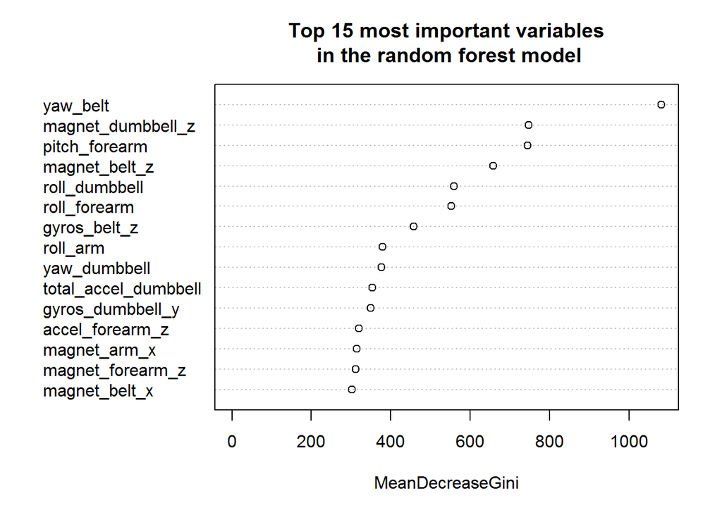

```r
varImpPlot(modelFit, main  = "Top 15 most important variables\n in the random forest model",
          scale=TRUE, n.var=15)
```

**Predictions with testdata** Using the most accurate model, the random forest model, I correctly predicted 20 variables of unknown “classe”.

```r
as.character(predict(modelFit, newdata=testdata))
```

```
##  [1] "B" "A" "B" "A" "A" "E" "D" "B" "A" "A" "B" "C" "B" "A" "E" "E" "A"
## [18] "B" "B" "B"
```

**Conclusions** Of the models created to predict activity class from the HAR dataset, the random forest model performed the best with an accuracy of 99% and a low OOB error rate .84.